While pandas adopts many coding idioms from NumPy, the biggest difference is that pandas is designed for working with tabular or heterogeneous data. NumPy, by contrast, is best suited for working with homogeneous numerical array data

```python
import pandas as pd
import numpy as np
```

# 5.1.Introduction to pandas Data Structures

## Series

```python
obj=pd.Series([4,7,-5,3])
obj
```

```
0    4
1    7
2   -5
3    3
dtype: int64
```

```python
obj.values
```

```
array([ 4,  7, -5,  3], dtype=int64)
```

```python
obj.index
```

```
RangeIndex(start=0, stop=4, step=1)
```

```python
obj2=pd.Series([4,7,-5,3],index=['d','b','a','c'])
obj2
```

```
d    4
b    7
a   -5
c    3
dtype: int64
```

```python
obj2.index
```

```
Index(['d', 'b', 'a', 'c'], dtype='object')
```

```python
obj.values==obj2.values
```

```
array([ True,  True,  True,  True])
```

```python
obj2['a']
```

```
-5
```

```python
obj2['d']=6
obj2[['c','a','d']]
```

```
c    3
a   -5
d    6
dtype: int64
```

```python
obj2[obj2>0]
```

```
d    6
b    7
c    3
dtype: int64
```

```python
np.exp(obj2)          #numpy 의 연산도 되는듯?
```

```
d     403.428793
b    1096.633158
a       0.006738
c      20.085537
dtype: float64
```

```python
sdata = {'Ohio': 35000, 'Texas': 71000, 'Oregon': 16000, 'Utah': 5000}
obj3=pd.Series(sdata)
print(obj3.values,obj3.dtype,type(obj3.values))            #값을 call 할 때는 numpy 로 나간다.
print(obj3.index)
```

```
[35000 71000 16000  5000] int64 <class 'numpy.ndarray'>
Index(['Ohio', 'Texas', 'Oregon', 'Utah'], dtype='object')
```

```python
sdata = {'Ohio': 35000, 'Texas': 71000, 'Oregon': 16000, 'Utah': 5000}
states = ['California', 'Ohio', 'Oregon', 'Texas']
obj4=pd.Series(sdata,index=states)
obj4
```

```
California        NaN
Ohio          35000.0
Oregon        16000.0
Texas         71000.0
dtype: float64
```

```python
print(pd.isnull(obj4))
print(pd.notnull(obj4))
```

```
California     True
Ohio          False
Oregon        False
Texas         False
dtype: bool
California    False
Ohio           True
Oregon         True
Texas          True
dtype: bool
```

뭔가 값을 call 할 때는 numpy 로 나가기 때문에 대부분 사용 가능한듯.

```python
print(pd.notnull(obj4).any())        #뭔가 값을 call 할 때는 numpy 로 나가기 때문에 대부분 사용 가능한듯.
print(pd.notnull(obj4).all())
```

```
True
False
```

```python
print(obj3)
print(obj4)
print(obj3+obj4)
```

```
Ohio      35000
Texas     71000
Oregon    16000
Utah       5000
dtype: int64
California        NaN
Ohio          35000.0
Oregon        16000.0
Texas         71000.0
dtype: float64
California         NaN
Ohio           70000.0
Oregon         32000.0
Texas         142000.0
Utah               NaN
dtype: float64
```

```python
obj=pd.Series(np.arange(5))
print(obj)
obj.index=['Bod','Steve','Jeff','Ryan','Sam']
print(obj)
```

```
0    0
1    1
2    2
3    3
4    4
dtype: int32
Bod      0
Steve    1
Jeff     2
Ryan     3
Sam      4
dtype: int32
```

## DataFrame

#### DataFrame Basic

```python
data = {'state': ['Ohio', 'Ohio', 'Ohio', 'Nevada', 'Nevada', 'Nevada'],
        'year': [2000, 2001, 2002, 2001, 2002, 2003],
        'pop': [1.5, 1.7, 3.6, 2.4, 2.9, 3.2]}
frame=pd.DataFrame(data)
frame
```

|  | state | year | pop |
| --- | --- | --- | --- |
| 0 | Ohio | 2000 | 1.5 |
| 1 | Ohio | 2001 | 1.7 |
| 2 | Ohio | 2002 | 3.6 |
| 3 | Nevada | 2001 | 2.4 |
| 4 | Nevada | 2002 | 2.9 |
| 5 | Nevada | 2003 | 3.2 |

```python
frame.head()
```

|  | state | year | pop |
| --- | --- | --- | --- |
| 0 | Ohio | 2000 | 1.5 |
| 1 | Ohio | 2001 | 1.7 |
| 2 | Ohio | 2002 | 3.6 |
| 3 | Nevada | 2001 | 2.4 |
| 4 | Nevada | 2002 | 2.9 |

```python
data = {'state': ['Ohio', 'Ohio', 'Ohio', 'Nevada', 'Nevada', 'Nevada'],
        'year': [2000, 2001, 2002, 2001, 2002, 2003],
        'pop': [1.5, 1.7, 3.6, 2.4, 2.9, 3.2]}
pd.DataFrame(data,columns=['year','state','pop','notindict'])   #없는거는 NaN 으로 나온다.
```

|  | year | state | pop | notindict |
| --- | --- | --- | --- | --- |
| 0 | 2000 | Ohio | 1.5 | NaN |
| 1 | 2001 | Ohio | 1.7 | NaN |
| 2 | 2002 | Ohio | 3.6 | NaN |
| 3 | 2001 | Nevada | 2.4 | NaN |
| 4 | 2002 | Nevada | 2.9 | NaN |
| 5 | 2003 | Nevada | 3.2 | NaN |

#### indexing

```python
data = {'state': ['Ohio', 'Ohio', 'Ohio', 'Nevada', 'Nevada', 'Nevada'],
        'year': [2000, 2001, 2002, 2001, 2002, 2003],
        'pop': [1.5, 1.7, 3.6, 2.4, 2.9, 3.2]}
frame2 = pd.DataFrame(data, columns=['year', 'state', 'pop', 'debt'],
                      index=['one', 'two', 'three', 'four', 'five', 'six'])
frame2
```

|  | year | state | pop | debt |
| --- | --- | --- | --- | --- |
| one | 2000 | Ohio | 1.5 | NaN |
| two | 2001 | Ohio | 1.7 | NaN |
| three | 2002 | Ohio | 3.6 | NaN |
| four | 2001 | Nevada | 2.4 | NaN |
| five | 2002 | Nevada | 2.9 | NaN |
| six | 2003 | Nevada | 3.2 | NaN |

```python
frame2['state']
```

```
one        Ohio
two        Ohio
three      Ohio
four     Nevada
five     Nevada
six      Nevada
Name: state, dtype: object
```

```python
frame2.state
```

```
one        Ohio
two        Ohio
three      Ohio
four     Nevada
five     Nevada
six      Nevada
Name: state, dtype: object
```

```python
frame2.loc['three']
```

```
year     2002
state    Ohio
pop       3.6
debt      NaN
Name: three, dtype: object
```

```python
frame2.debt=[2,3,2,2,5,5]
frame2
```

|  | year | state | pop | debt |
| --- | --- | --- | --- | --- |
| one | 2000 | Ohio | 1.5 | 2 |
| two | 2001 | Ohio | 1.7 | 3 |
| three | 2002 | Ohio | 3.6 | 2 |
| four | 2001 | Nevada | 2.4 | 2 |
| five | 2002 | Nevada | 2.9 | 5 |
| six | 2003 | Nevada | 3.2 | 5 |

```python
val=pd.Series([-1.2,-1.5,-1.7],index=['two','four','five'])
frame2['debt']=val
frame2
```

|  | year | state | pop | debt |
| --- | --- | --- | --- | --- |
| one | 2000 | Ohio | 1.5 | NaN |
| two | 2001 | Ohio | 1.7 | -1.2 |
| three | 2002 | Ohio | 3.6 | NaN |
| four | 2001 | Nevada | 2.4 | -1.5 |
| five | 2002 | Nevada | 2.9 | -1.7 |
| six | 2003 | Nevada | 3.2 | NaN |

```python
frame2['eastern']= (frame2.state=='Ohio')
frame2
```

|  | year | state | pop | debt | eastern |
| --- | --- | --- | --- | --- | --- |
| one | 2000 | Ohio | 1.5 | NaN | True |
| two | 2001 | Ohio | 1.7 | -1.2 | True |
| three | 2002 | Ohio | 3.6 | NaN | True |
| four | 2001 | Nevada | 2.4 | -1.5 | False |
| five | 2002 | Nevada | 2.9 | -1.7 | False |
| six | 2003 | Nevada | 3.2 | NaN | False |

```python
del frame2['eastern']
frame2.columns
```

```
Index(['year', 'state', 'pop', 'debt'], dtype='object')
```

#### nested dict , transpose, 축 각각은 index와 columns

```python
pop = {'Nevada': {2001: 2.4, 2002: 2.9}, 'Ohio': {2000: 1.5, 2001: 1.7, 2002: 3.6}}
frame3=pd.DataFrame(pop)
frame3
```

|  | Nevada | Ohio |
| --- | --- | --- |
| 2001 | 2.4 | 1.7 |
| 2002 | 2.9 | 3.6 |
| 2000 | NaN | 1.5 |

```python
frame3.T
```

|  | 2001 | 2002 | 2000 |
| --- | --- | --- | --- |
| Nevada | 2.4 | 2.9 | NaN |
| Ohio | 1.7 | 3.6 | 1.5 |

```python
pop = {'Nevada': {2001: 2.4, 2002: 2.9}, 'Ohio': {2000: 1.5, 2001: 1.7, 2002: 3.6}}
pd.DataFrame(pop,index=[2001,2002,2003])
```

|  | Nevada | Ohio |
| --- | --- | --- |
| 2001 | 2.4 | 1.7 |
| 2002 | 2.9 | 3.6 |
| 2003 | NaN | NaN |

```python
pop = {  'Nevada': {2001: 2.4, 2002: 2.9}, 'Ohio': {2000: 1.5, 2001: 1.7, 2002: 3.6}  }
frame3=pd.DataFrame(pop)
pdata={'Ohio':frame3['Ohio'][:-1], 'Nevada':frame3['Nevada'][:2]}         #인덱싱이 dataframe 상에서 되는듯.
pd.DataFrame(pdata)
```

|  | Ohio | Nevada |
| --- | --- | --- |
| 2001 | 1.7 | 2.4 |
| 2002 | 3.6 | 2.9 |

```python
frame3.index.name='year'; frame3.columns.name='state'
frame3
```

| state year | Nevada | Ohio |
| --- | --- | --- |
| 2001 | 2.4 | 1.7 |
| 2002 | 2.9 | 3.6 |
| 2000 | NaN | 1.5 |

```python
print(frame3.values,'\n',frame3.index,'\n',frame3.columns)    #columns 도 Index object 라는 것을 알 수 있음.
```

```
[[2.4 1.7]
 [2.9 3.6]
 [nan 1.5]]
 Int64Index([2001, 2002, 2000], dtype='int64', name='year')
 Index(['Nevada', 'Ohio'], dtype='object', name='state')
```

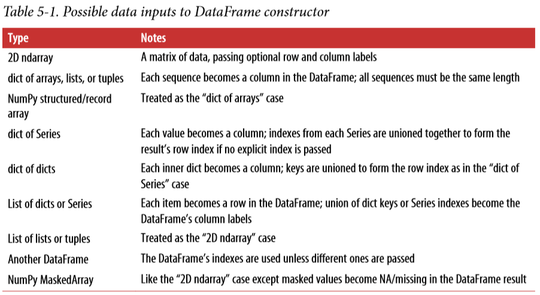

## Index Objects : cannot be modified by user

Index objects are immutable and thus can’t be modified by the user:

```python
obj=pd.Series(range(3),index=['a','b','c'])
index=obj.index
print(index)
print(index[1:])
```

```
Index(['a', 'b', 'c'], dtype='object')
Index(['b', 'c'], dtype='object')
```

```python
#index[1]='d' 는 TypeError 이다. 때문에 modify 하고 싶다면 다른 것으로 바꾼 후 넘어와야 한다.
temp=np.array(index)
temp[1]='d'
index=pd.Index(temp)
index
```

```
Index(['a', 'd', 'c'], dtype='object')
```

```python
row=pd.Index(['a','b','c'])
obj=pd.Series([1,2,3],index=row)
obj
```

```
a    1
b    2
c    3
dtype: int64
```

index object 는 list 이면서 set, ndarray 연산도 되는듯 하다

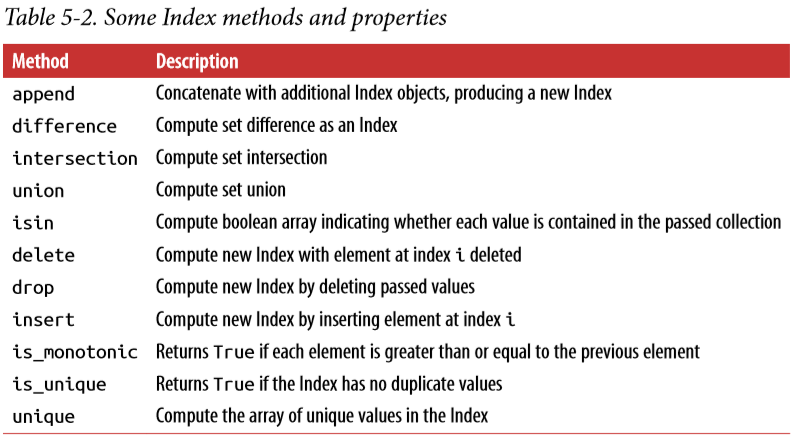

```python
index1=pd.Index(['a','b','a','b','d','c'])
index2=pd.Index(['a'])
index1.append(index2)
print(index1)
print(np.unique(index1))
```

```
Index(['a', 'b', 'a', 'b', 'd', 'c'], dtype='object')
['a' 'b' 'c' 'd']
```

# 5.2.Essential Functionality

## Reindexing : data.reindex(pd.Index)

```python
obj=pd.Series([4.5,7.2,-5.3,3.6],index=['d','b','a','c'])
obj2=obj.reindex(['a','b','c','d','e'])
print(obj)
print(obj2)
```

```
d    4.5
b    7.2
a   -5.3
c    3.6
dtype: float64
a   -5.3
b    7.2
c    3.6
d    4.5
e    NaN
dtype: float64
```

reindex 에서 사용하는 argument 들은 다음과 같다.

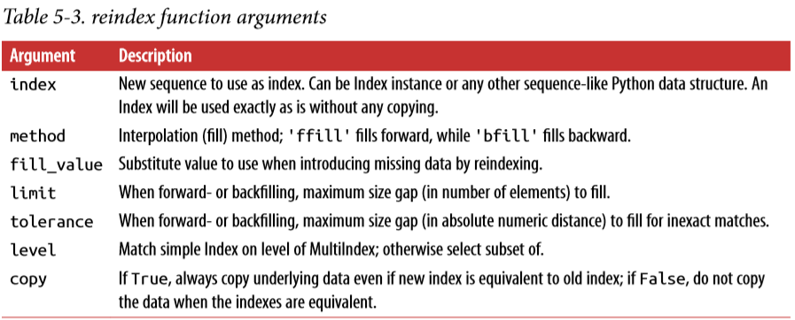

For ordered data like time series, it may be desirable to do some interpolation or filling of values when reindexing. The method option allows us to do this, using a method such as ffill, which forward-fills the values:

```python
obj3=pd.Series(['blue','purple','yellow'],index=[0,2,4])
obj4=obj3.reindex(range(6),method='ffill')
print(obj3)
print(obj4)
```

```
0      blue
2    purple
4    yellow
dtype: object
0      blue
1      blue
2    purple
3    purple
4    yellow
5    yellow
dtype: object
```

```python
frame=pd.DataFrame(np.arange(9).reshape((3,3)),index=['a','c','d'],columns=['Ohio','Texas','California'])
print(frame)
frame2=frame.reindex(['a','b','c','d'],method='bfill')
print(frame2)
```

```
   Ohio  Texas  California
a     0      1           2
c     3      4           5
d     6      7           8
   Ohio  Texas  California
a     0      1           2
b     3      4           5
c     3      4           5
d     6      7           8
```

```python
frame=pd.DataFrame(np.arange(9).reshape((3,3)),index=['a','c','d'],columns=['Ohio','Texas','California'])
states=['Texas','Utah','California']
print(  frame.reindex(columns=states)  )
```

```
   Texas  Utah  California
a      1   NaN           2
c      4   NaN           5
d      7   NaN           8
```

## Dropping Entries from an Axis : data.drop('a',axis=0), inplace

```python
obj=pd.Series(np.arange(5.),index=['a','b','c','d','e'])
obj2=obj.drop('c')
obj3=obj.drop(['d','c'])
print(obj)
print(obj2)
print(obj3)
```

```
a    0.0
b    1.0
c    2.0
d    3.0
e    4.0
dtype: float64
a    0.0
b    1.0
d    3.0
e    4.0
dtype: float64
a    0.0
b    1.0
e    4.0
dtype: float64
```

```python
data=pd.DataFrame(np.arange(16).reshape((4,4)),index=['Ohio', 'Colorado', 'Utah', 'New York'],columns=['one', 'two', 'three', 'four'])
print(data)
print(data.drop(['Colorado','Ohio']))
print(data.drop('two',axis=1))
print(data.drop(['two','four'],axis='columns'))
```

```
          one  two  three  four
Ohio        0    1      2     3
Colorado    4    5      6     7
Utah        8    9     10    11
New York   12   13     14    15
          one  two  three  four
Utah        8    9     10    11
New York   12   13     14    15
          one  three  four
Ohio        0      2     3
Colorado    4      6     7
Utah        8     10    11
New York   12     14    15
          one  three
Ohio        0      2
Colorado    4      6
Utah        8     10
New York   12     14
```

inplace=True 옵션을 사용하면 새로운 오브젝트를 생성하지 않고 원본에 그대로 씌운다.

```python
data=pd.DataFrame(np.arange(16).reshape((4,4)),index=['Ohio', 'Colorado', 'Utah', 'New York'],columns=['one', 'two', 'three', 'four'])
data.drop(['Ohio','Colorado'],inplace=True)
print(data)
```

```
          one  two  three  four
Utah        8    9     10    11
New York   12   13     14    15
```

## Indexing, Selection, and Filtering

```python
obj=pd.Series(np.arange(4.),index=['a','b','c','d'])
print(obj['b'])
print(obj[obj>2])
print(obj[[1,3]])
print(obj[1:3])
```

```
1.0
d    3.0
dtype: float64
b    1.0
d    3.0
dtype: float64
b    1.0
c    2.0
dtype: float64
```

```python
data=pd.DataFrame(np.arange(16).reshape((4,4)),index=['Ohio', 'Colorado', 'Utah', 'New York'],columns=['one', 'two', 'three', 'four'])
print(data['two'])
print(data[['three','one']])
print(data[:2])
print(data[data['three']>5])
```

```
Ohio         1
Colorado     5
Utah         9
New York    13
Name: two, dtype: int32
          three  one
Ohio          2    0
Colorado      6    4
Utah         10    8
New York     14   12
          one  two  three  four
Ohio        0    1      2     3
Colorado    4    5      6     7
          one  two  three  four
Colorado    4    5      6     7
Utah        8    9     10    11
New York   12   13     14    15
```

```python
data=pd.DataFrame(np.arange(16).reshape((4,4)),index=['Ohio', 'Colorado', 'Utah', 'New York'],columns=['one', 'two', 'three', 'four'])
data[data<5]=0
print(data)
```

```
          one  two  three  four
Ohio        0    0      0     0
Colorado    0    5      6     7
Utah        8    9     10    11
New York   12   13     14    15
```

## Selection with loc and iloc

When originally designing pandas, I felt that having to type frame[:, col] to select a column was too verbose (and errorprone), since column selection is one of the most common operations. I made the design trade-off to push all of the fancy indexing behavior (both labels and integers) into the ix operator. In practice, this led to many edge cases in data with integer axis labels, so the pandas team decided to create the loc and iloc operators to deal with strictly label-based and integer-based indexing, respectively.

numpy 처럼 data[rowindex,colindex] 로 불러올 수가 없다. 동시 indexing을 위해서는 loc 이나 iloc 을 사용해야 한다.

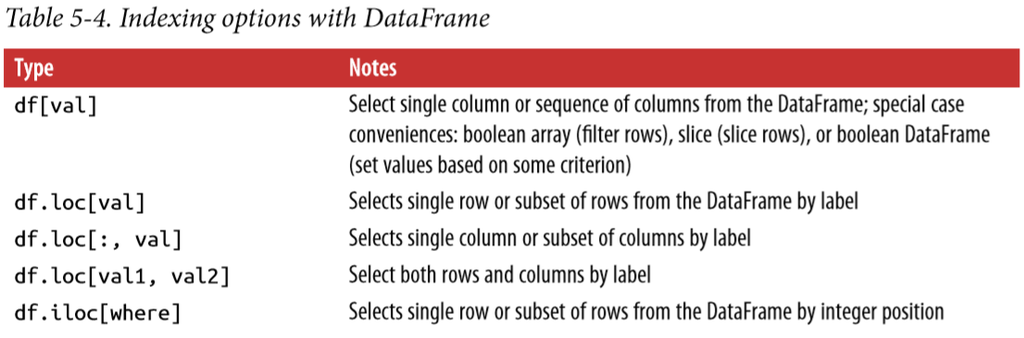

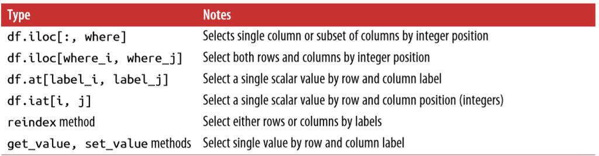

```python
data=pd.DataFrame(np.arange(16).reshape((4,4)),index=['Ohio', 'Colorado', 'Utah', 'New York'],columns=['one', 'two', 'three', 'four'])
print(data['one'])
print(data.loc['Ohio'])        #그리고 이렇게 불러온 object 는 pd.Series 라는 것을 기억하자.
print(data.loc['Ohio','one'])
```

```
Ohio         0
Colorado     4
Utah         8
New York    12
Name: one, dtype: int32
one      0
two      1
three    2
four     3
Name: Ohio, dtype: int32
0
```

```python
data=pd.DataFrame(np.arange(16).reshape((4,4)),index=['Ohio', 'Colorado', 'Utah', 'New York'],columns=['one', 'two', 'three', 'four'])
print(data.iloc[0,0])
```

```
0
```

index 에 integer가 들어가 있으면 slicing 에서 ambiguity 가 발생하기 때문에 iloc 을 습관적으로 사용하는 것이 좋다.

```python
ser=pd.Series(np.arange(3.))
#print(ser[-1])  this gives ambiguity what'-1' menas
print(ser.iloc[-1])
ser=pd.Series(np.arange(3.),index=list('abc'))       #with a non-integer index, there is no potential for ambiguity:
print(ser[-1])
```

```
2.0
2.0
```

## Arithmetic and Data Alignment

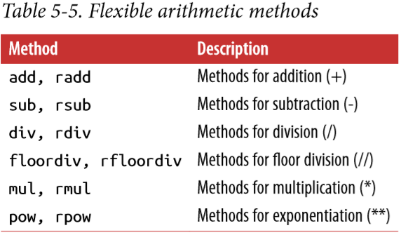

Series+Series

```python
s1=pd.Series([7.3, -2.5, 3.4, 1.5], index=['a', 'c', 'd', 'e'])
s2= pd.Series([-2.1, 3.6, -1.5, 4, 3.1], index=['a', 'c', 'e', 'f', 'g'])
print(s1+s2)
print(s1.add(s2,fill_value=0))
```

```
a    5.2
c    1.1
d    NaN
e    0.0
f    NaN
g    NaN
dtype: float64
a    5.2
c    1.1
d    3.4
e    0.0
f    4.0
g    3.1
dtype: float64
```

DataFrame+DataFrame

```python
df1=pd.DataFrame(np.arange(9.).reshape((3,3)), columns=list('bcd'),index=['Ohio','Texas','Colorado'] )
df2=pd.DataFrame(np.arange(12.).reshape((4,3)), columns=list('bcd'),index=['Utah', 'Ohio', 'Texas', 'Oregon'])
print(df1)
print(df2)
print(df1+df2)
print(df1.add(df2,fill_value=0))   #만약 df1에 column 'e' 가 있었다면 [Utah,e] 는 둘 모두에게 없으므로 NaN 결과가 나온다.
```

```
            b    c    d
Ohio      0.0  1.0  2.0
Texas     3.0  4.0  5.0
Colorado  6.0  7.0  8.0
          b     c     d
Utah    0.0   1.0   2.0
Ohio    3.0   4.0   5.0
Texas   6.0   7.0   8.0
Oregon  9.0  10.0  11.0
            b     c     d
Colorado  NaN   NaN   NaN
Ohio      3.0   5.0   7.0
Oregon    NaN   NaN   NaN
Texas     9.0  11.0  13.0
Utah      NaN   NaN   NaN
            b     c     d
Colorado  6.0   7.0   8.0
Ohio      3.0   5.0   7.0
Oregon    9.0  10.0  11.0
Texas     9.0  11.0  13.0
Utah      0.0   1.0   2.0
```

```python
df1=pd.DataFrame(np.arange(12.).reshape((3,4)),columns=list('abcd'))
df2=pd.DataFrame(np.arange(20.).reshape((4,5)),columns=list('abcde'))
df2.loc[1,'b']=np.nan
print(df1)
print(df2)
print(df1+df2)
print(df1.add(df2,fill_value=0))
```

```
     a    b     c     d
0  0.0  1.0   2.0   3.0
1  4.0  5.0   6.0   7.0
2  8.0  9.0  10.0  11.0
      a     b     c     d     e
0   0.0   1.0   2.0   3.0   4.0
1   5.0   NaN   7.0   8.0   9.0
2  10.0  11.0  12.0  13.0  14.0
3  15.0  16.0  17.0  18.0  19.0
      a     b     c     d   e
0   0.0   2.0   4.0   6.0 NaN
1   9.0   NaN  13.0  15.0 NaN
2  18.0  20.0  22.0  24.0 NaN
3   NaN   NaN   NaN   NaN NaN
      a     b     c     d     e
0   0.0   2.0   4.0   6.0   4.0
1   9.0   5.0  13.0  15.0   9.0
2  18.0  20.0  22.0  24.0  14.0
3  15.0  16.0  17.0  18.0  19.0
```

```python
df1=pd.DataFrame(np.arange(12.).reshape((3,4)),columns=list('abcd'))
print(1/df1)
print(df1.div(1))    #  df1 에서 1   을 나눔
print(df1.rdiv(1))   #   1  에서 df1 을 나눔
```

```
       a         b         c         d
0    inf  1.000000  0.500000  0.333333
1  0.250  0.200000  0.166667  0.142857
2  0.125  0.111111  0.100000  0.090909
     a    b     c     d
0  0.0  1.0   2.0   3.0
1  4.0  5.0   6.0   7.0
2  8.0  9.0  10.0  11.0
       a         b         c         d
0    inf  1.000000  0.500000  0.333333
1  0.250  0.200000  0.166667  0.142857
2  0.125  0.111111  0.100000  0.090909
```

```python
df1=pd.DataFrame(np.arange(12.).reshape((3,4)),columns=list('abcd'))
df2=pd.DataFrame(np.arange(20.).reshape((4,5)),columns=list('abcde'))
df1=df1.reindex(columns=df2.columns, fill_value=0)
print(df1)
```

```
     a    b     c     d  e
0  0.0  1.0   2.0   3.0  0
1  4.0  5.0   6.0   7.0  0
2  8.0  9.0  10.0  11.0  0
```

DataFrame+Series : 넘파이와 판다의 데이터 저장방식이 아주 유사하다.

```python
#similar to numpy..
arr=np.arange(12.).reshape((3,4))
print(arr)
print(arr[0])
print(arr-arr[0])
```

```
[[ 0.  1.  2.  3.]
 [ 4.  5.  6.  7.]
 [ 8.  9. 10. 11.]]
[0. 1. 2. 3.]
[[0. 0. 0. 0.]
 [4. 4. 4. 4.]
 [8. 8. 8. 8.]]
```

```python
frame=pd.DataFrame(np.arange(12.).reshape((4,3)),columns=list('bde'),index=['Utah','Ohio','Texas','Oregon'])
series=frame.iloc[0]
print(frame)
print(series)
print(frame-series)
```

```
          b     d     e
Utah    0.0   1.0   2.0
Ohio    3.0   4.0   5.0
Texas   6.0   7.0   8.0
Oregon  9.0  10.0  11.0
b    0.0
d    1.0
e    2.0
Name: Utah, dtype: float64
          b    d    e
Utah    0.0  0.0  0.0
Ohio    3.0  3.0  3.0
Texas   6.0  6.0  6.0
Oregon  9.0  9.0  9.0
```

```python
frame=pd.DataFrame(np.arange(12.).reshape((4,3)),columns=list('bde'),index=['Utah','Ohio','Texas','Oregon'])
series2=pd.Series(range(3),index=['b','e','f'])
print(series2)
print(frame+series2)
print(frame.add(series2))   #여기서는 fill_value 가 안먹네...?
```

```
b    0
e    1
f    2
dtype: int64
          b   d     e   f
Utah    0.0 NaN   3.0 NaN
Ohio    3.0 NaN   6.0 NaN
Texas   6.0 NaN   9.0 NaN
Oregon  9.0 NaN  12.0 NaN
          b   d     e   f
Utah    0.0 NaN   3.0 NaN
Ohio    3.0 NaN   6.0 NaN
Texas   6.0 NaN   9.0 NaN
Oregon  9.0 NaN  12.0 NaN
```

```python
frame=pd.DataFrame(np.arange(12.).reshape((4,3)),columns=list('bde'),index=['Utah','Ohio','Texas','Oregon'])
series3=frame['d']
print(frame)
print(series3)
print(frame-series3)
print(frame.sub(series3,axis='index'))
```

```
          b     d     e
Utah    0.0   1.0   2.0
Ohio    3.0   4.0   5.0
Texas   6.0   7.0   8.0
Oregon  9.0  10.0  11.0
Utah       1.0
Ohio       4.0
Texas      7.0
Oregon    10.0
Name: d, dtype: float64
        Ohio  Oregon  Texas  Utah   b   d   e
Utah     NaN     NaN    NaN   NaN NaN NaN NaN
Ohio     NaN     NaN    NaN   NaN NaN NaN NaN
Texas    NaN     NaN    NaN   NaN NaN NaN NaN
Oregon   NaN     NaN    NaN   NaN NaN NaN NaN
          b    d    e
Utah   -1.0  0.0  1.0
Ohio   -1.0  0.0  1.0
Texas  -1.0  0.0  1.0
Oregon -1.0  0.0  1.0
```

## Function Application and Mapping : df.apply(f, axis=), df.applymap(f), Ser.map(f)

```python
frame=pd.DataFrame(np.random.randn(4,3),columns=list('bde'),index=['Utah','Ohio','Texas','Oregon'])
f=lambda x:x.max()-x.min()     #numpy array 에서 사용가능한 max, min (4장 Mathematical and Statistical Methods)
print(frame)
print(f(frame))  #exactly same as 'frame.apply(f)''
print(frame.apply(f,axis=1))
```

```
               b         d         e
Utah    0.855824  0.708263 -0.673565
Ohio    1.128907  0.979811  2.674716
Texas  -1.135683  0.516555  1.118943
Oregon -0.300754 -0.579994  1.091437
b    2.264590
d    1.559806
e    3.348281
dtype: float64
Utah      1.529389
Ohio      1.694904
Texas     2.254626
Oregon    1.671431
dtype: float64
```

```python
f=lambda x:pd.Series([x.min(),x.max()],index=['min','max'])
frame.apply(f)
```

|  | b | d | e |
| --- | --- | --- | --- |
| min | -1.135683 | -0.579994 | -0.673565 |
| max | 1.128907 | 0.979811 | 2.674716 |

```python
f=lambda x:'%.2f'%x
print(frame.applymap(f))      #elementwise 함수는 DF 와 SER 가 다르다. applymap & map
print(frame['e'].map(f))
```

```
            b      d      e
Utah     0.86   0.71  -0.67
Ohio     1.13   0.98   2.67
Texas   -1.14   0.52   1.12
Oregon  -0.30  -0.58   1.09
Utah      -0.67
Ohio       2.67
Texas      1.12
Oregon     1.09
Name: e, dtype: object
```

## Sorting and Ranking : sort_index(), sort_values(), rank()

sort_index(axis= ,ascending= )

```python
obj=pd.Series(range(4),index=['d','a','b','c'])
obj.sort_index()
```

```
a    1
b    2
c    3
d    0
dtype: int64
```

```python
frame=pd.DataFrame(np.arange(8).reshape((2,4)),index=['three','one'],columns=['d','a','b','c'])
print(frame.sort_index())
print(frame.sort_index(axis=1))
print(frame.sort_index(axis=1).sort_index(axis=0))
print(frame.sort_index(axis=1,ascending=False))
```

```
       d  a  b  c
one    4  5  6  7
three  0  1  2  3
       a  b  c  d
three  1  2  3  0
one    5  6  7  4
       a  b  c  d
one    5  6  7  4
three  1  2  3  0
       d  c  b  a
three  0  3  2  1
one    4  7  6  5
```

sort_values(by= ) -- NaN 은 항상 뒤에 간다

When sorting a DataFrame, you can use the data in one or more columns as the sort keys. To do so, pass one or more column names to the by option of sort_values:

```python
obj=pd.Series([4,np.nan,7,np.nan,-3,2])
print(obj.sort_values())
print(obj.sort_values(ascending=False))
```

```
4   -3.0
5    2.0
0    4.0
2    7.0
1    NaN
3    NaN
dtype: float64
2    7.0
0    4.0
5    2.0
4   -3.0
1    NaN
3    NaN
dtype: float64
```

```python
frame=pd.DataFrame({'b':[4,7,-3,2],'a':[0,1,0,1]})
print(frame)
print(frame.sort_values(by='b'))
print(frame.sort_values(by=['a','b']))   #a를 기준으로 sorting 하되 같으면 b를 따른다.
```

```
   b  a
0  4  0
1  7  1
2 -3  0
3  2  1
   b  a
2 -3  0
3  2  1
0  4  0
1  7  1
   b  a
2 -3  0
0  4  0
3  2  1
1  7  1
```

Ranking assigns ranks from one through the number of valid data points in an array. The rank methods for Series and DataFrame are the place to look; by default rank breaks ties by assigning each group the mean rank:

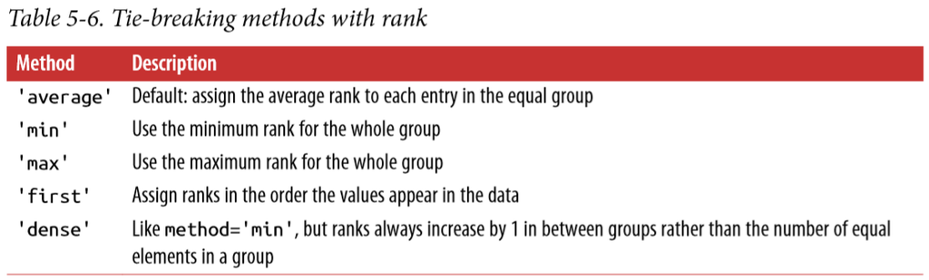

```python
obj=pd.Series([1,1,1,2,3,4,4,5,6,7])   #같은것이면 그들의 평균(1의 경우 1,2,3 의 평균인 2 할당)
obj.rank()
```

```
0     2.0
1     2.0
2     2.0
3     4.0
4     5.0
5     6.5
6     6.5
7     8.0
8     9.0
9    10.0
dtype: float64
```

```python
obj=pd.Series([7,-5,7,4,2,0,4])
obj.rank()
```

```
0    6.5
1    1.0
2    6.5
3    4.5
4    3.0
5    2.0
6    4.5
dtype: float64
```

```python
obj=pd.Series([7,-5,7,4,2,0,4])
obj.rank(method='first')        #같은것을 처리할 때 앞에것을 먼저
```

```
0    6.0
1    1.0
2    7.0
3    4.0
4    3.0
5    2.0
6    5.0
dtype: float64
```

```python
obj=pd.Series([7,-5,7,4,2,0,4])
obj.rank(ascending=False, method='max')    #같은것을 처리할 때 가장 큰 것으로
```

[output not shown]

```python
frame = pd.DataFrame({'b': [4.3, 7, -3, 2], 'a': [0, 1, 0, 1], 'c': [-2, 5, 8, -2.5]})
print(frame)
print(frame.rank(axis='columns'))   #column 이 바뀌면서 적용된다고 생각...
```

```
     b  a    c
0  4.3  0 -2.0
1  7.0  1  5.0
2 -3.0  0  8.0
3  2.0  1 -2.5
     b    a    c
0  3.0  2.0  1.0
1  3.0  1.0  2.0
2  1.0  2.0  3.0
3  3.0  2.0  1.0
```

## Axis Indexes with Duplicate Labels

Data selection is one of the main things that behaves differently with duplicates. Indexing a label with multiple entries returns a Series, while single entries return a scalar value:

```python
obj=pd.Series(range(5),index=['a','a','b','b','c'])
print(obj)
print(obj.index.is_unique)
```

```
a    0
a    1
b    2
b    3
c    4
dtype: int64
False
```

```python
obj['a']
```

```
a    0
a    1
dtype: int64
```

```python
obj['c']
```

```
4
```

# 5.3.Summarizing and Computing Descriptive Statistics

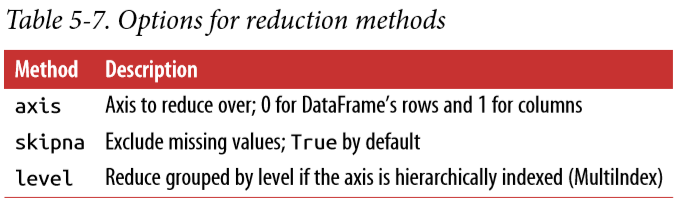

```python
df = pd.DataFrame([[1.4, np.nan], [7.1, -4.5], [np.nan, np.nan], [0.75, -1.3]], index=['a', 'b', 'c', 'd'], columns=['one', 'two'])
df
```

|  | one | two |
| --- | --- | --- |
| a | 1.40 | NaN |
| b | 7.10 | -4.5 |
| c | NaN | NaN |
| d | 0.75 | -1.3 |

```python
df.sum()
```

```
one    9.25
two   -5.80
dtype: float64
```

```python
df.sum(axis='columns')
```

```
a    1.40
b    2.60
c    0.00
d   -0.55
dtype: float64
```

```python
df.sum(axis='columns',skipna=False)
```

```
a     NaN
b    2.60
c     NaN
d   -0.55
dtype: float64
```

```python
df.idxmax()
```

```
one    b
two    d
dtype: object
```

```python
df.cumsum()
```

|  | one | two |
| --- | --- | --- |
| a | 1.40 | NaN |
| b | 8.50 | -4.5 |
| c | NaN | NaN |
| d | 9.25 | -5.8 |

## .describe()

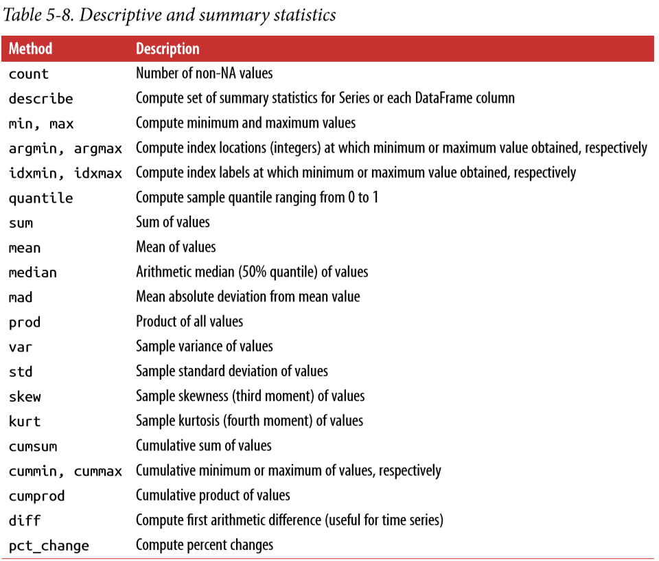

```python
df = pd.DataFrame([[1.4, np.nan], [7.1, -4.5], [np.nan, np.nan], [0.75, -1.3]], index=['a', 'b', 'c', 'd'], columns=['one', 'two'])
df.describe()
```

|  | one | two |
| --- | --- | --- |
| count | 3.000000 | 2.000000 |
| mean | 3.083333 | -2.900000 |
| std | 3.493685 | 2.262742 |
| min | 0.750000 | -4.500000 |
| 25% | 1.075000 | -3.700000 |
| 50% | 1.400000 | -2.900000 |
| 75% | 4.250000 | -2.100000 |
| max | 7.100000 | -1.300000 |

```python
obj=pd.Series(['a','a','b','c']*4)  #non-numeric data
obj.describe()
```

```
count     16
unique     3
top        a
freq       8
dtype: object
```

## Correlation and Covariance : ser.corr(ser) / df.corr() / df.corrwith(ser) / .pct_change()

```python
import pandas_datareader.data as web
all_data={ticker: web.get_data_yahoo(ticker) for ticker in ['AAPL','IBM','MSFT','GOOG']}
```

```python
df=all_data['AAPL']
df.head()
```

| Date | High | Low | Open | Close | Volume | Adj Close |
| --- | --- | --- | --- | --- | --- | --- |
| 2015-05-20 | 130.979996 | 129.339996 | 130.000000 | 130.059998 | 36454900.0 | 119.864433 |
| 2015-05-21 | 131.630005 | 129.830002 | 130.070007 | 131.389999 | 39730400.0 | 121.090179 |
| 2015-05-22 | 132.970001 | 131.399994 | 131.600006 | 132.539993 | 45596000.0 | 122.150032 |
| 2015-05-26 | 132.910004 | 129.119995 | 132.600006 | 129.619995 | 70697600.0 | 119.458923 |
| 2015-05-27 | 132.259995 | 130.050003 | 130.339996 | 132.039993 | 45833200.0 | 121.689232 |

```python
df.tail()
```

| Date | High | Low | Open | Close | Volume | Adj Close |
| --- | --- | --- | --- | --- | --- | --- |
| 2020-05-12 | 319.690002 | 310.910004 | 317.829987 | 311.410004 | 40575300.0 | 311.410004 |
| 2020-05-13 | 315.950012 | 303.209991 | 312.149994 | 307.649994 | 50155600.0 | 307.649994 |
| 2020-05-14 | 309.790009 | 301.529999 | 304.510010 | 309.540009 | 39732300.0 | 309.540009 |
| 2020-05-15 | 307.899994 | 300.209991 | 300.350006 | 307.709991 | 41587100.0 | 307.709991 |
| 2020-05-18 | 316.500000 | 310.320007 | 313.170013 | 314.959991 | 33794600.0 | 314.959991 |

```python
price=pd.DataFrame({ticker:data['Adj Close'] for ticker,data in all_data.items()})
volume=pd.DataFrame({ticker:data['Volume'] for ticker,data in all_data.items()})
volume.head()
```

| Date | AAPL | IBM | MSFT | GOOG |
| --- | --- | --- | --- | --- |
| 2015-05-20 | 36454900.0 | 2300300.0 | 25047900.0 | 1430800 |
| 2015-05-21 | 39730400.0 | 2295600.0 | 22410700.0 | 1462700 |
| 2015-05-22 | 45596000.0 | 2849700.0 | 25720600.0 | 1176200 |
| 2015-05-26 | 70697600.0 | 3854200.0 | 29581900.0 | 2406500 |
| 2015-05-27 | 45833200.0 | 2764400.0 | 27335600.0 | 1525000 |

```python
returns=price.pct_change()
returns.head()
```

| Date | AAPL | IBM | MSFT | GOOG |
| --- | --- | --- | --- | --- |
| 2015-05-20 | NaN | NaN | NaN | NaN |
| 2015-05-21 | 0.010226 | -0.002417 | -0.003363 | 0.006008 |
| 2015-05-22 | 0.008753 | -0.006461 | -0.010966 | -0.004424 |
| 2015-05-26 | -0.022031 | -0.012136 | -0.006610 | -0.014423 |
| 2015-05-27 | 0.018670 | 0.010991 | 0.021893 | 0.014033 |

```python
returns.tail()
```

| Date | AAPL | IBM | MSFT | GOOG |
| --- | --- | --- | --- | --- |
| 2020-05-12 | -0.011428 | -0.019006 | -0.022652 | -0.019611 |
| 2020-05-13 | -0.012074 | -0.037668 | -0.015122 | -0.019197 |
| 2020-05-14 | 0.006143 | 0.010542 | 0.004339 | 0.005040 |
| 2020-05-15 | -0.005912 | 0.000257 | 0.014568 | 0.012580 |
| 2020-05-18 | 0.023561 | 0.039152 | 0.009554 | 0.007828 |

```python
returns['MSFT'].corr(returns['IBM'])
```

```
0.5998234128542698
```

```python
returns['MSFT'].cov(returns['IBM'])
```

```
0.00016255731566731165
```

```python
returns.corr()
```

|  | AAPL | IBM | MSFT | GOOG |
| --- | --- | --- | --- | --- |
| AAPL | 1.000000 | 0.533519 | 0.710516 | 0.642348 |
| IBM | 0.533519 | 1.000000 | 0.599823 | 0.529732 |
| MSFT | 0.710516 | 0.599823 | 1.000000 | 0.751235 |
| GOOG | 0.642348 | 0.529732 | 0.751235 | 1.000000 |

```python
returns.corrwith(returns.IBM)
```

```
AAPL    0.533519
IBM     1.000000
MSFT    0.599823
GOOG    0.529732
dtype: float64
```

```python
returns.corrwith(volume)
```

```
AAPL   -0.141819
IBM    -0.105628
MSFT   -0.066178
GOOG   -0.039205
dtype: float64
```

```python
returns.corrwith(volume,axis=1)
```

```
Date
2015-05-20         NaN
2015-05-21    0.447704
2015-05-22    0.635427
2015-05-26   -0.595147
2015-05-27    0.764087
                ...
2020-05-12    0.444317
2020-05-13    0.708019
2020-05-14   -0.481915
2020-05-15   -0.075667
2020-05-18   -0.240263
Length: 1258, dtype: float64
```

## Unique Values, Value Counts, and Membership : isin, match, unique, value_counts

```python
obj=pd.Series(['c', 'a', 'd', 'a', 'a', 'b', 'b', 'c', 'c'])
obj.unique()
```

```
array(['c', 'a', 'd', 'b'], dtype=object)
```

```python
obj.value_counts()
```

```
c    3
a    3
b    2
d    1
dtype: int64
```

```python
pd.value_counts(obj.values,sort=False)
```

```
d    1
b    2
a    3
c    3
dtype: int64
```

```python
mask=obj.isin(['b','c'])
mask
```

```
0     True
1    False
2    False
3    False
4    False
5     True
6     True
7     True
8     True
dtype: bool
```

```python
obj[mask]
```

```
0    c
5    b
6    b
7    c
8    c
dtype: object
```

```python
to_match=pd.Series(['c','a','b','b','c','a','d','f'])
unique_vals=pd.Series(['c','b','a'])
pd.Index(unique_vals).get_indexer(to_match)
```

```
array([ 0,  2,  1,  1,  0,  2, -1, -1], dtype=int64)
```

```python
data=pd.DataFrame(np.random.randn(3,5),index=['Qu1','Qu2','Qu3'])
data
```

|  | 0 | 1 | 2 | 3 | 4 |
| --- | --- | --- | --- | --- | --- |
| Qu1 | 0.316828 | 0.590544 | 2.114435 | 0.418137 | -0.084558 |
| Qu2 | -0.435358 | 0.165603 | -0.126228 | 1.264298 | 0.299051 |
| Qu3 | 0.405421 | 0.577456 | 0.417486 | -1.877885 | -0.804693 |

```python
data.apply(pd.value_counts)
```

|  | 0 | 1 | 2 | 3 | 4 |
| --- | --- | --- | --- | --- | --- |
| -1.877885 | NaN | NaN | NaN | 1.0 | NaN |
| -0.804693 | NaN | NaN | NaN | NaN | 1.0 |
| -0.435358 | 1.0 | NaN | NaN | NaN | NaN |
| -0.126228 | NaN | NaN | 1.0 | NaN | NaN |
| -0.084558 | NaN | NaN | NaN | NaN | 1.0 |
| 0.165603 | NaN | 1.0 | NaN | NaN | NaN |
| 0.299051 | NaN | NaN | NaN | NaN | 1.0 |
| 0.316828 | 1.0 | NaN | NaN | NaN | NaN |
| 0.405421 | 1.0 | NaN | NaN | NaN | NaN |
| 0.417486 | NaN | NaN | 1.0 | NaN | NaN |
| 0.418137 | NaN | NaN | NaN | 1.0 | NaN |
| 0.577456 | NaN | 1.0 | NaN | NaN | NaN |
| 0.590544 | NaN | 1.0 | NaN | NaN | NaN |
| 1.264298 | NaN | NaN | NaN | 1.0 | NaN |
| 2.114435 | NaN | NaN | 1.0 | NaN | NaN |

```python
data.apply(pd.value_counts).fillna(0)
```

|  | 0 | 1 | 2 | 3 | 4 |
| --- | --- | --- | --- | --- | --- |
| -1.877885 | 0.0 | 0.0 | 0.0 | 1.0 | 0.0 |
| -0.804693 | 0.0 | 0.0 | 0.0 | 0.0 | 1.0 |
| -0.435358 | 1.0 | 0.0 | 0.0 | 0.0 | 0.0 |
| -0.126228 | 0.0 | 0.0 | 1.0 | 0.0 | 0.0 |
| -0.084558 | 0.0 | 0.0 | 0.0 | 0.0 | 1.0 |
| 0.165603 | 0.0 | 1.0 | 0.0 | 0.0 | 0.0 |
| 0.299051 | 0.0 | 0.0 | 0.0 | 0.0 | 1.0 |
| 0.316828 | 1.0 | 0.0 | 0.0 | 0.0 | 0.0 |
| 0.405421 | 1.0 | 0.0 | 0.0 | 0.0 | 0.0 |
| 0.417486 | 0.0 | 0.0 | 1.0 | 0.0 | 0.0 |
| 0.418137 | 0.0 | 0.0 | 0.0 | 1.0 | 0.0 |
| 0.577456 | 0.0 | 1.0 | 0.0 | 0.0 | 0.0 |
| 0.590544 | 0.0 | 1.0 | 0.0 | 0.0 | 0.0 |
| 1.264298 | 0.0 | 0.0 | 0.0 | 1.0 | 0.0 |
| 2.114435 | 0.0 | 0.0 | 1.0 | 0.0 | 0.0 |